# Assignment 2: Machine Learning

Linzi Yu

```r
library(glmnet)
library(ROCR)
library(MASS)
```

# Logistics

Please check Canvas for the due date of this assignment. Please be sure to answer all parts of each question and submit your answers as a knitted .html file: select the Knit drop down at the top of the window. Once converted to .html, select the file in the file browser, click the More drop down, and select Export.

# Background

In class, we discussed two broad subfields of machine learning: supervised learning and unsupervised learning. In a typical supervised learning setup, we use a set of labeled input data points to try and learn a robust function that maps future inputs to labels. By contrast, in unsupervised learning, we do not have labels for our training data, and instead we seek to understand interesting things about the data such as the correlation structure between variables or whether high-dimensional data points can be projected into a lower-dimensional space without much loss of information. In this assignment, we will explore both approaches to machine learning using the same dataset.

## Part 1: Supervised Learning

Your clinician collaborator has collected a dataset of blood laboratory values, basic demographic information (age, gender), and coronary artery disease status from a population of ~1K individuals. The data is available in **hw2_2022.rds**.

```r
library(tidyverse)
hw2.data <- readRDS('hw2_2022.rds')
```

### Question 1

This dataset derives from CDC NHANES and consists of blood lab values (prefixed with ‘LBX’) as well as coronary artery disease (CAD) status (variable “cad” with 0 = absent, 1 = present), age, and gender. Write a code snippet to count the number of cases and controls in the dataset, and report these two numbers here:

```r
hw2.data %>% group_by(cad) %>% summarise(count = n())
```

```
## # A tibble: 2 × 2
##     cad count
##   <dbl> <int>
## 1     0   684
## 2     1   395
```

- 684 controls, 395 cases

### Question 2

Your clinician collaborator asks you to build a new lab-based “score” that can tell whether a new individual has CAD or not given their laboratory values, gender, and age. Is this a prediction or inference task?

- Prediction.

### Question 3

Your collaborator suggests you use the whole dataset, try as many complex models as you can run, and select the best one to publish. You inform your collaborator that we could do this but it might be a bad idea because of a trade-off called:

- The bias-variance trade-off

### Question 4

Write down the equation for the trade-off from Q3.

- Error(x) = Bias^2 + Variance + Irreducible Error

### Question 5

You suggest to your collaborator that you should divide the sample into a training and test dataset. Write a function called “train_test_split” that accepts “hw2.data” as an input and returns an R list object containing two [“tibbles”](https://tibble.tidyverse.org/): “train” and “test” in a 70:30 random split.

```r
train_test_split <- function(hw2.data) {
  hw2.train <- hw2.data %>% sample_frac(0.7)
  hw2.test <- anti_join(hw2.data, hw2.train, by = NULL)
  train_test_split <- list()
  train_test_split[[1]] <- hw2.train
  train_test_split[[2]] <- hw2.test
  return(train_test_split)
}
```

### Question 6

What type of regression is a good first statistical model to use for binary classification (such as 0/1 status of coronary artery disease)? [Hint: It’s not linear regression.] How is this model different than linear regression?

- Logistic regression. The dependent variable y in logistic regression is binary instead of continuous in linear regression.

### Question 7

Write R code to fit the model you named in Q6 to predict “cad” from labs and demographics. You should use “train_test_split” from Q5 to fit the model on the “train” data with R’s “glm” function. Evaluate the model’s performance on the “test” data and report the accuracy and plot an ROC curve. Report the AUC. Hint: use the “ROCR” package.

```r
# your code here
train <- train_test_split(hw2.data)[[1]]
test <- train_test_split(hw2.data)[[2]]
# Run logistic regression model
set.seed(37)
train_mod <- glm(cad ~ ., data = train, family = 'binomial')
summary(train_mod)
```

```
##
## Call:
## glm(formula = cad ~ ., family = "binomial", data = train)
##
## Deviance Residuals:
##     Min       1Q   Median       3Q      Max
## -2.6317  -0.6545  -0.2048   0.6659   2.7745
##
## Coefficients: (1 not defined because of singularities)
##               Estimate Std. Error z value Pr(>|z|)
## (Intercept)  1.027e+02  1.440e+02   0.713 0.476012
## LBXWBCSI     7.175e-02  6.052e-02   1.186 0.235800
## LBXLYPCT    -7.404e-01  1.375e+00  -0.539 0.590158
## LBXMOPCT    -7.105e-01  1.373e+00  -0.518 0.604806
## LBXNEPCT    -7.505e-01  1.375e+00  -0.546 0.585111
## LBXEOPCT    -7.139e-01  1.378e+00  -0.518 0.604543
## LBXBAPCT    -7.748e-01  1.374e+00  -0.564 0.572830
## LBXRBCSI    -1.782e+00  2.252e+00  -0.791 0.428784
## LBXHGB      -1.858e+00  1.414e+00  -1.314 0.188925
## LBXHCT       8.815e-01  5.709e-01   1.544 0.122563
## LBXMCVSI    -8.316e-01  4.050e-01  -2.053 0.040044 *
## LBXMCHSI     2.183e+00  1.086e+00   2.010 0.044399 *
## LBXMC       -7.740e-01  9.861e-01  -0.785 0.432522
## LBXRDW       2.452e-01  1.099e-01   2.230 0.025714 *
## LBXPLTSI    -4.078e-03  2.033e-03  -2.006 0.044841 *
## LBXMPSI     -2.095e-02  1.307e-01  -0.160 0.872648
## LBXSAL       1.551e-01  4.515e-01   0.344 0.731150
## LBXSATSI    -4.367e-03  1.050e-02  -0.416 0.677619
## LBXSASSI     9.391e-04  1.199e-02   0.078 0.937568
## LBXSAPSI     4.888e-03  4.619e-03   1.058 0.289862
## LBXSBU      -5.205e-02  4.859e-02  -1.071 0.284117
## LBXSCA      -4.908e-01  3.451e-01  -1.422 0.154956
## LBXSCH      -9.731e-03  1.884e-02  -0.516 0.605521
## LBXSC3SI     9.975e-02  7.027e-02   1.419 0.155770
## LBXSGTSI    -3.364e-04  3.952e-03  -0.085 0.932171
## LBXSGL      -5.555e-03  7.726e-03  -0.719 0.472118
## LBXSIR      -4.615e-03  4.097e-03  -1.126 0.259985
## LBXSLDSI     5.841e-03  3.379e-03   1.729 0.083884 .
## LBXSPH       1.224e-01  2.045e-01   0.599 0.549390
## LBXSTB       6.416e-01  4.917e-01   1.305 0.191900
```

[output cut: 15 more lines]

```
## LBXCOT      -2.969e-04  1.062e-03  -0.280 0.779781
## LBXRBFSI     1.642e-04  2.645e-04   0.621 0.534829
## LBXFOLSI    -7.359e-03  4.670e-03  -1.576 0.115100
## age          8.156e-02  9.892e-03   8.244  < 2e-16 ***
## gender      -2.225e-01  2.865e-01  -0.777 0.437293
## ---
## Signif. codes:  0 '***' 0.001 '**' 0.01 '*' 0.05 '.' 0.1 ' ' 1
##
## (Dispersion parameter for binomial family taken to be 1)
##
##     Null deviance: 998.83  on 754  degrees of freedom
## Residual deviance: 628.14  on 706  degrees of freedom
## AIC: 726.14
##
## Number of Fisher Scoring iterations: 6
```

```r
# Perform prediction on test data
set.seed(37)
predict <- predict(train_mod, test, type = 'response')
# Calculate confusion matrix
mat <- table(test$cad, predict > 0.5)
mat # FALSE = predicted to be negative; TRUE = predicted to be positive; 0 = Truth of no cad; 1 = Truth of cad
```

```
##
##     FALSE TRUE
##   0   181   39
##   1    31   73
```

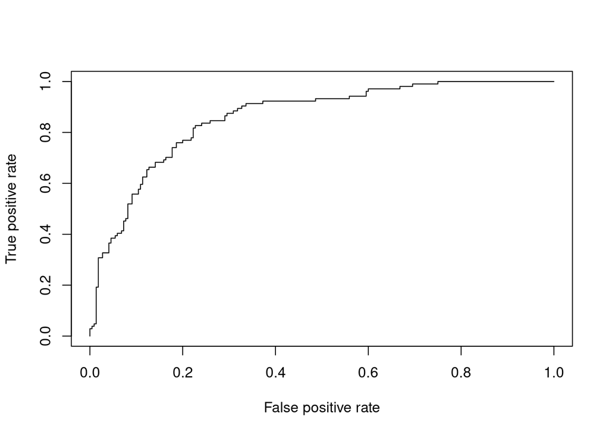

```r
# Calculate the model accuracy by summing the true positive + true negative over the total observation
accuracy <- sum(diag(mat)) / sum(mat)
# Plot ROC curve
library(ROCR)
ROCRpred <- prediction(predict, test$cad)
ROCRperf <- performance(ROCRpred, 'tpr', 'fpr')
plot(ROCRperf)
```

```r
# get the AUC value
auc_ROCR <- performance(ROCRpred, measure = "auc")
auc_ROCR <- auc_ROCR@y.values[[1]]
cat("Accuracy of the model is ", accuracy , ". (Accuracy calculated by true positive + true negative over the total observation)")
```

```
## Accuracy of the model is  0.7839506 . (Accuracy calculated by true positive + true negative over the total observation)
```

```r
cat("AUC =", auc_ROCR)
```

```
## AUC = 0.8593531
```

### Question 8

Is this a good predictor? What would a random CAD predictor yield? Write R code to verify the accuracy of a random prediction.

```r
# Run logistic regression model
train_syn <- train %>% mutate(cad = sample(cad))
set.seed(37)
train_rand <- glm(cad ~ ., data = train_syn, family = 'binomial')
summary(train_rand)
```

```
##
## Call:
## glm(formula = cad ~ ., family = "binomial", data = train_syn)
##
## Deviance Residuals:
##     Min       1Q   Median       3Q      Max
## -1.6117  -0.9716  -0.7856   1.2642   2.0029
##
## Coefficients: (1 not defined because of singularities)
##               Estimate Std. Error z value Pr(>|z|)
## (Intercept)  1.555e+01  1.104e+02   0.141  0.88802
## LBXWBCSI     2.937e-02  3.654e-02   0.804  0.42160
## LBXLYPCT    -2.487e-01  1.044e+00  -0.238  0.81179
## LBXMOPCT    -2.415e-01  1.044e+00  -0.231  0.81716
## LBXNEPCT    -2.387e-01  1.045e+00  -0.228  0.81926
## LBXEOPCT    -2.446e-01  1.049e+00  -0.233  0.81556
## LBXBAPCT    -3.210e-01  1.048e+00  -0.306  0.75945
## LBXRBCSI     3.059e-01  1.654e+00   0.185  0.85327
## LBXHGB       4.077e-01  1.101e+00   0.370  0.71106
## LBXHCT      -1.659e-01  4.471e-01  -0.371  0.71059
## LBXMCVSI     1.557e-01  3.140e-01   0.496  0.61996
## LBXMCHSI    -4.158e-01  8.418e-01  -0.494  0.62132
## LBXMC        1.464e-01  7.718e-01   0.190  0.84957
## LBXRDW      -8.742e-03  7.924e-02  -0.110  0.91216
## LBXPLTSI    -3.877e-04  1.573e-03  -0.246  0.80533
## LBXMPSI     -4.899e-02  9.930e-02  -0.493  0.62176
## LBXSAL      -3.429e-01  3.466e-01  -0.989  0.32250
## LBXSATSI    -8.172e-04  7.542e-03  -0.108  0.91372
## LBXSASSI     2.739e-03  9.798e-03   0.280  0.77982
## LBXSAPSI     1.448e-03  3.678e-03   0.394  0.69373
## LBXSBU      -3.307e-02  4.876e-02  -0.678  0.49761
## LBXSCA      -1.024e-01  2.787e-01  -0.367  0.71331
## LBXSCH       1.742e-02  1.465e-02   1.189  0.23440
## LBXSC3SI    -1.600e-03  5.590e-02  -0.029  0.97716
## LBXSGTSI     8.742e-04  2.985e-03   0.293  0.76961
## LBXSGL      -1.125e-02  7.851e-03  -1.433  0.15181
## LBXSIR      -4.571e-03  2.977e-03  -1.535  0.12473
## LBXSLDSI    -1.207e-04  1.818e-03  -0.066  0.94708
## LBXSPH      -3.999e-02  1.582e-01  -0.253  0.80043
## LBXSTB       9.259e-01  3.474e-01   2.665  0.00769 **
```

[output cut: 15 more lines]

```
## LBXCOT       1.745e-04  7.816e-04   0.223  0.82332
## LBXRBFSI     2.113e-04  2.000e-04   1.056  0.29079
## LBXFOLSI     1.922e-03  3.198e-03   0.601  0.54781
## age         -5.992e-03  6.116e-03  -0.980  0.32721
## gender      -2.818e-01  2.291e-01  -1.230  0.21877
## ---
## Signif. codes:  0 '***' 0.001 '**' 0.01 '*' 0.05 '.' 0.1 ' ' 1
##
## (Dispersion parameter for binomial family taken to be 1)
##
##     Null deviance: 998.83  on 754  degrees of freedom
## Residual deviance: 960.55  on 706  degrees of freedom
## AIC: 1058.5
##
## Number of Fisher Scoring iterations: 4
```

```r
# Perform prediction on test data
set.seed(37)
predict_rand <- predict(train_rand, test, type = 'response')
# Calculate confusion matrix
mat_rand <- table(test$cad, predict_rand > 0.5)
mat_rand # FALSE = predicted to be negative; TRUE = predicted to be positive; 0 = Truth of no cad; 1 = Truth of cad
```

```
##
##     FALSE TRUE
##   0   197   23
##   1    84   20
```

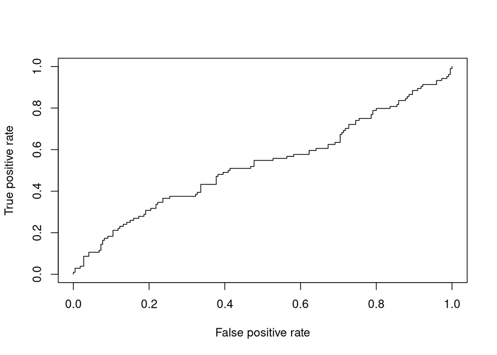

```r
# Calculate the model accuracy by summing the true positive + true negative over the total observation
accuracy_rand <- sum(diag(mat_rand)) / sum(mat_rand)
# Plot ROC curve
library(ROCR)
ROCRpred_rand <- prediction(predict_rand, test$cad)
ROCRperf_rand <- performance(ROCRpred_rand, 'tpr', 'fpr')
plot(ROCRperf_rand, text.adj = c(-0.2, 1.7))
```

```r
# get the AUC value
auc_ROCR_rand <- performance(ROCRpred_rand, measure = "auc")
auc_ROCR_rand <- auc_ROCR_rand@y.values[[1]]
cat("Accuracy of the model is ", accuracy_rand , ". (Accuracy calculated by true positive + true negative over the total observation)")
```

```
## Accuracy of the model is  0.6697531 . (Accuracy calculated by true positive + true negative over the total observation)
```

```r
cat("AUC =", auc_ROCR_rand)
```

```
## AUC = 0.5289336
```

### Question 9

You suggest that a model that has some regularization may be helpful. Explain this idea to your clinical colleague. Also indicate which of the pictures below depicts L1 and which depicts L2 regularization.

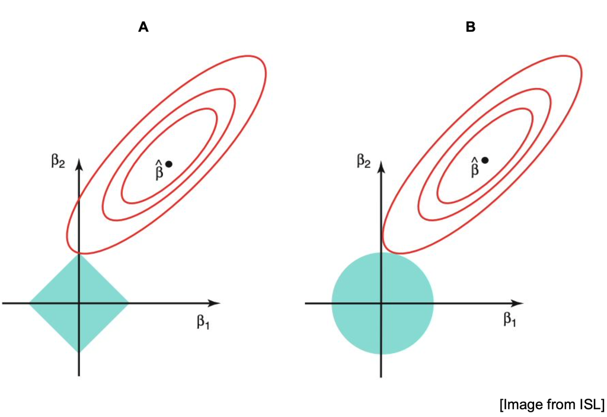

- We need to adjust the model to prevent overfitting, so that it is more generalizable when predicting a new dataset.

- Left: Lasso regularization/L1
- Right: ridge regularization/L2

### Question 10

Use the “glmnet” package to regularize your model [Hint: see http://web.stanford.edu/~hastie/glmnet/glmnet_alpha.html; R package already installed on the server] with the same “train” “test” datasets. Report the same performance measures as in Q7 and plot and ROC curve. Compare model performance for the non-regularized (Q7) and the regularized model and speculate on why performance did/did not improve.

```r
# your code here
#fit <- glmnet(x, y, alpha = 0.2, weights = wts, nlambda = 50)
x.train <- train %>% select(-cad) %>% as.matrix()
y.train <- train %>% select(cad) %>% as.matrix()
x.test <- test %>% select(-cad) %>% as.matrix()
y.test <- test %>% select(cad) %>% as.matrix()
# use cross validation to obtain the optimal value of lambda (in cv.glmnet, x and y must be passed separately); set alpha = 1 for lasso regression in this case to reduce non related variables; family binomial to do logistic regression.
set.seed(37)
lasso.cv <- cv.glmnet(x.train, y.train, alpha = 1, family = 'binomial', type.measure="class") # Also, we can try elastic net regression by testing multiple alpha values
set.seed(37)
lasso.fit <- glmnet(x.train, y.train, alpha = 1, family = 'binomial')

# Use the previous fit model to predict on test data.
set.seed(37)
lasso.predicted <- predict(lasso.fit, s=lasso.cv$lambda.1se, newx=x.test, type="response") #use 1se to generate model with fewer parameters

# Calculate confusion matrix
mat_reg <- table(test$cad, lasso.predicted > 0.5)
mat_reg # FALSE = predicted to be negative; TRUE = predicted to be positive; 0 = Truth of no cad; 1 = Truth of cad
```

```
##
##     FALSE TRUE
##   0   182   38
##   1    29   75
```

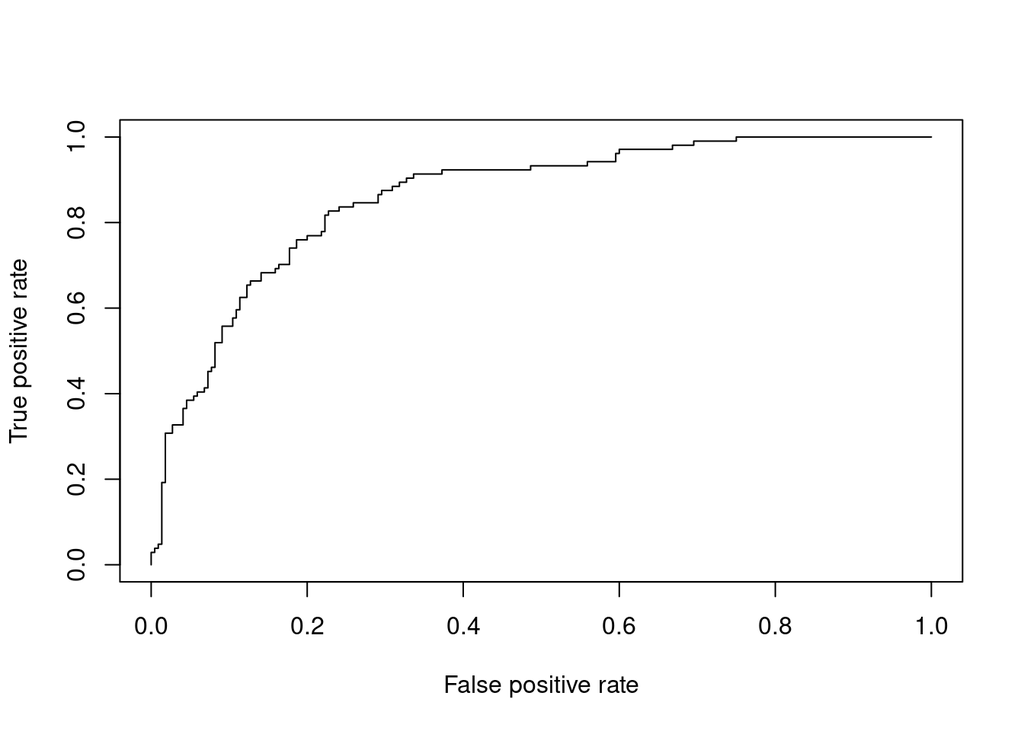

```r
# Calculate the model accuracy by summing the true positive + true negative over the total observation
accuracy_reg <- sum(diag(mat)) / sum(mat)

# Plot ROC curve
ROCRpred_reg <- prediction(lasso.predicted, test$cad)
ROCRperf_reg <- performance(ROCRpred_reg, 'tpr', 'fpr')
plot(ROCRperf)
```

```r
# get the AUC value
auc_ROCR_reg <- performance(ROCRpred_reg, measure = "auc")
auc_ROCR_reg <- auc_ROCR_reg@y.values[[1]]

cat("Accuracy of the model is ", accuracy_reg , ". (Accuracy calculated by true positive + true negative over the total observation)")
```

[output not shown]

```r
cat("AUC =", auc_ROCR_reg)
```

```
## AUC = 0.8590035
```

## Part 2: Unsupervised Learning

Now let’s switch gears to unsupervised learning. First we’ll simulate a dataset with known correlation structure and then we’ll explore the same coronary artery disease dataset from Part 1 using techniques from unsupervised learning.

### Question 11

Consider a toy dataset consisting of four variables, x1, x2, x3, and x4. Write an R function called “simulate” that simulates 10,000 observations of such a dataset with only two constraints: that the correlation = 0.8 between x1 and x2 and the correlation = 0.55 between x3 and x4 [Hint: use the mvrnorm function from the R package “MASS” already installed on the server].

```r
# your code here
# Assume the mean of all variables = 0, variance of all variables = 1, write function
simulation <- function(n = 10000, seed=37){
  #setting the covariance matrix values. The "2,2" part defines the number of rows and columns
  sigma1 <- matrix(c(1, 0.8, 0.8, 1), 2,2)  # set the correlation of 0.8 for variable x1 and x1
  sigma2 <- matrix(c(1, 0.55, 0.55, 1), 2,2)  # set the correlation of 0.55 for variable x3 and x4
  #set the seed value
  set.seed(seed)
  #simulate the data, as specified above
  sim1 <- mvrnorm(n, mu = c(0,0), Sigma = sigma1)
  sim2 <- mvrnorm(n, mu = c(0,0), Sigma = sigma2)
  sim <- cbind(sim1, sim2)
  colnames(sim) <- c('x1','x2','x3','x4')
  return(data.frame(sim))
}
```

### Question 12

Regress x2 ~ x1 and x1 ~ x2, report the intercepts and slopes and R^2 values, and compare the results with what you expected based on writing “simulate”. What are the two separate regression equations optimizing?

```r
# your code here
toydata <- simulation()
lm1 <- lm(x2 ~ x1, data = toydata)
lm2 <- lm(x1 ~ x2, data = toydata)
summary(lm1)
```

```
##
## Call:
## lm(formula = x2 ~ x1, data = toydata)
##
## Residuals:
##      Min       1Q   Median       3Q      Max
## -2.07541 -0.40311 -0.00017  0.40473  2.22018
##
## Coefficients:
##              Estimate Std. Error t value Pr(>|t|)
## (Intercept) -0.001732   0.005929  -0.292     0.77
## x1           0.802223   0.005856 136.989   <2e-16 ***
## ---
## Signif. codes:  0 '***' 0.001 '**' 0.01 '*' 0.05 '.' 0.1 ' ' 1
##
## Residual standard error: 0.5928 on 9998 degrees of freedom
## Multiple R-squared:  0.6524, Adjusted R-squared:  0.6524
## F-statistic: 1.877e+04 on 1 and 9998 DF,  p-value: < 2.2e-16
```

```r
summary(lm2)
```

```
##
## Call:
## lm(formula = x1 ~ x2, data = toydata)
##
## Residuals:
##      Min       1Q   Median       3Q      Max
## -2.18751 -0.40898  0.00047  0.40625  2.38370
##
## Coefficients:
##             Estimate Std. Error t value Pr(>|t|)
## (Intercept) 0.003799   0.005969   0.636    0.525
## x2          0.813256   0.005937 136.989   <2e-16 ***
## ---
## Signif. codes:  0 '***' 0.001 '**' 0.01 '*' 0.05 '.' 0.1 ' ' 1
##
## Residual standard error: 0.5969 on 9998 degrees of freedom
## Multiple R-squared:  0.6524, Adjusted R-squared:  0.6524
## F-statistic: 1.877e+04 on 1 and 9998 DF,  p-value: < 2.2e-16
```

- x2 ~ x1 Regression intercept: -0.001732, slope: 0.802223, R^2: 0.6524
- x1 ~ x2 Regression intercept: 0.003799, slope: 0.813256, R^2: 0.6524
- The expected intercept is 0 (I assume mean of all variables = 0 in toy dateset), expected slope is 0.8, and R^2 is expected to be 0.64 (square of correlations).
- x2 ~ x1 model is doing regression over x1, it’s minimizing the sum of squared residuals over x2
- x1 ~ x2 model is doing regression over x2, it’s minimizing the sum of squared residuals over x1

### Question 13

Now run principal components analysis (PCA) using the “prcomp” function on (x1,x2,x3,x4). Plot PC1 and PC2. Does PCA identify interesting structure? What is PCA optimizing?

```r
# your code here
sim_ds <- simulation()
sim.pca <- prcomp(sim_ds,scale. = TRUE)

library(factoextra)
```

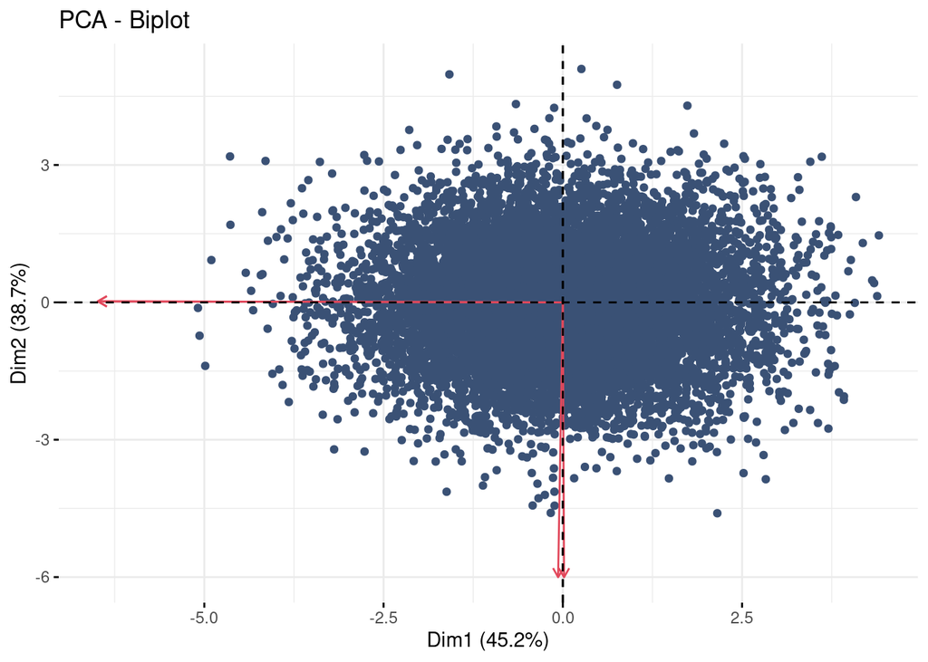

```r
fviz_pca_biplot(sim.pca, repel = TRUE, label = "none",
                col.var = "#E2485B",
                col.ind = "#3A5175"
                )
```

### Question 14

Plot the variance explained by successive principal components in this dataset.

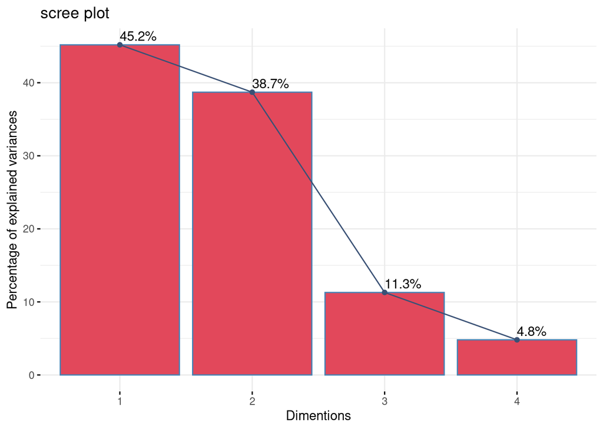

```r
# your code here
fviz_eig(sim.pca, addlabels=TRUE, barfill = "#E2485B", linecolor = "#3A5175")+
labs(title = "scree plot",
         x = "Dimentions", y = "Percentage of explained variances")
```

### Question 15

How many principal components summarize these data well? Explain your reasoning.

- 2, PC1 and PC2 together accounts for 83.9% variance of the dataset. For PC3 there’s a significant drop in the percentage, thus keeping two pcs gives simple description of the data.

### Question 16

Run PCA on all the blood labs in the full “hw2.data” dataset (make sure to select only variables that start with ‘LBX’). Make sure to center and scale PCA. Why is it important to center and scale? Plot the variance explained by principal component.

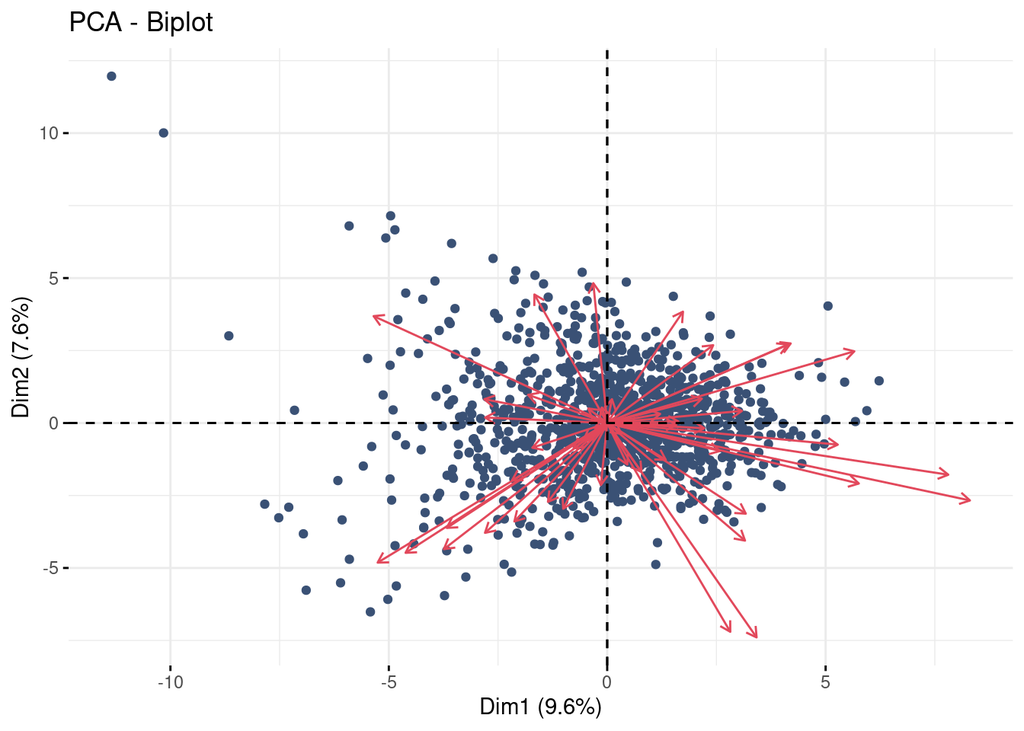

```r
# your code here
# select only lab results
hw2.lab <- hw2.data %>% select(-cad, -age, -gender)
hw2.pca <- prcomp(hw2.lab, center = TRUE, scale. = TRUE)
fviz_pca_biplot(hw2.pca, repel = TRUE, label = "none",
                col.var = "#E2485B",
                col.ind = "#3A5175"
                )
```

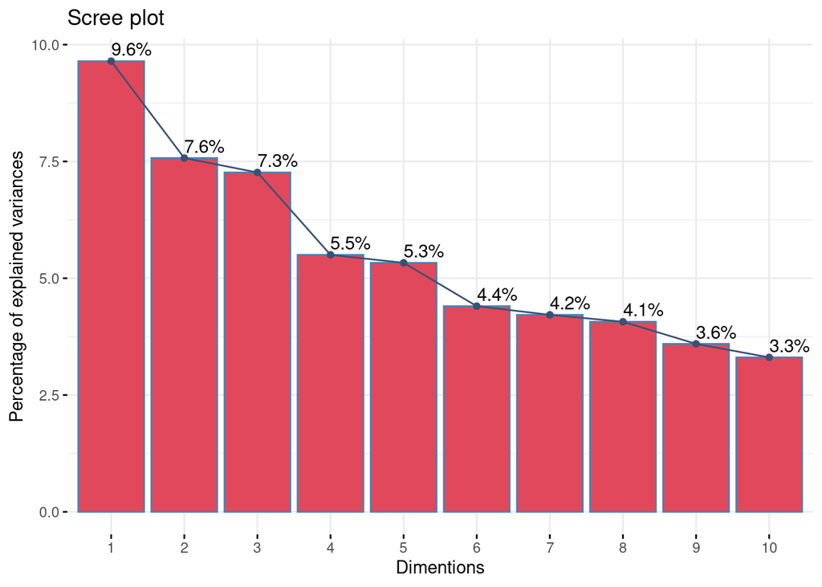

```r
fviz_eig(hw2.pca, addlabels=TRUE, barfill = "#E2485B", linecolor = "#3A5175")+
labs(title = "Scree plot",
         x = "Dimentions", y = "Percentage of explained variances")
```

- Centering can help to compare the variation of the data instead of the absolute value of the data. So when the PCs go through the origin point, it can span the direction of the most variations.
- Scaling different variables so that they are equivalent and comparable to each other, otherwise will cause biases towards one of them.

### Question 17

How many principal components summarize this data well? Plot PC1 and PC2 and color the projected points by CAD status. Is there structure visible in this plot by CAD status? Do these results align with your expectations from the supervised analysis conducted earlier?

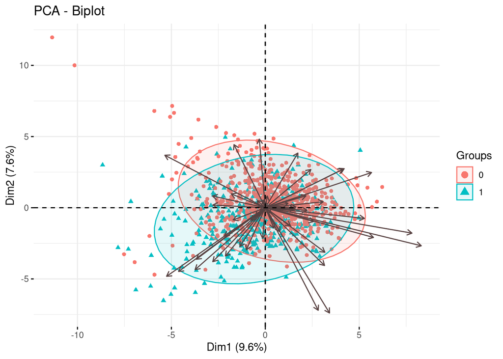

```r
# your code here
fviz_pca_biplot(hw2.pca, repel = TRUE, label = "none",
                col.var = "#574141",
                habillage=hw2.data$cad,
                addEllipses=TRUE, ellipse.level=0.95,
                ggtheme = theme_minimal())
```